# Exploring Data with the Tidyverse

Kelly Bodwin

# Examine the Data

## The Dataset

- Information about passengers on the HMS Titanic

```r
head(titanic)
```

```
##   Survived Pclass                                               Name
## 1        0      3                             Mr. Owen Harris Braund
## 2        1      1 Mrs. John Bradley (Florence Briggs Thayer) Cumings
## 3        1      3                              Miss. Laina Heikkinen
## 4        1      1        Mrs. Jacques Heath (Lily May Peel) Futrelle
## 5        0      3                            Mr. William Henry Allen
## 6        0      3                                    Mr. James Moran
##      Sex Age Siblings.Spouses.Aboard Parents.Children.Aboard    Fare
## 1   male  22                       1                       0  7.2500
## 2 female  38                       1                       0 71.2833
## 3 female  26                       0                       0  7.9250
## 4 female  35                       1                       0 53.1000
## 5   male  35                       0                       0  8.0500
## 6   male  27                       0                       0  8.4583
```

## What do we know?

```r
str(titanic)
```

```
## 'data.frame':    887 obs. of  8 variables:
##  $ Survived               : int  0 1 1 1 0 0 0 0 1 1 ...
##  $ Pclass                 : int  3 1 3 1 3 3 1 3 3 2 ...
##  $ Name                   : Factor w/ 887 levels "Capt. Edward Gifford Crosby",..: 602 823 172 814 733 464 700 33 842 839 ...
##  $ Sex                    : Factor w/ 2 levels "female","male": 2 1 1 1 2 2 2 2 1 1 ...
##  $ Age                    : num  22 38 26 35 35 27 54 2 27 14 ...
##  $ Siblings.Spouses.Aboard: int  1 1 0 1 0 0 0 3 0 1 ...
##  $ Parents.Children.Aboard: int  0 0 0 0 0 0 0 1 2 0 ...
##  $ Fare                   : num  7.25 71.28 7.92 53.1 8.05 ...
```

- How many passengers were there?
- What information did we collect about them?

```r
titanic[118,]
```

```
##     Survived Pclass                    Name  Sex Age
## 118        0      1 Mr. Quigg Edmond Baxter male  24
##     Siblings.Spouses.Aboard Parents.Children.Aboard     Fare
## 118                       0                       1 247.5208
```

Tell me about this person!

# Get a feel for the variables

## How many passengers survived?

```r
titanic %>% count(Survived)
```

```
## # A tibble: 2 x 2
##   Survived     n
##      <int> <int>
## 1        0   545
## 2        1   342
```

- Note that this information was only displayed, not saved!
- If you wanted to store your answer for later use…

```r
# base R
num_survived <- sum(titanic$Survived == 1)

# Tidyverse
num_survived <-  titanic %>%
  tally(Survived == 1) %>%
  pull(n)
## try it without the "pull(n)" step.  What is the difference?
```

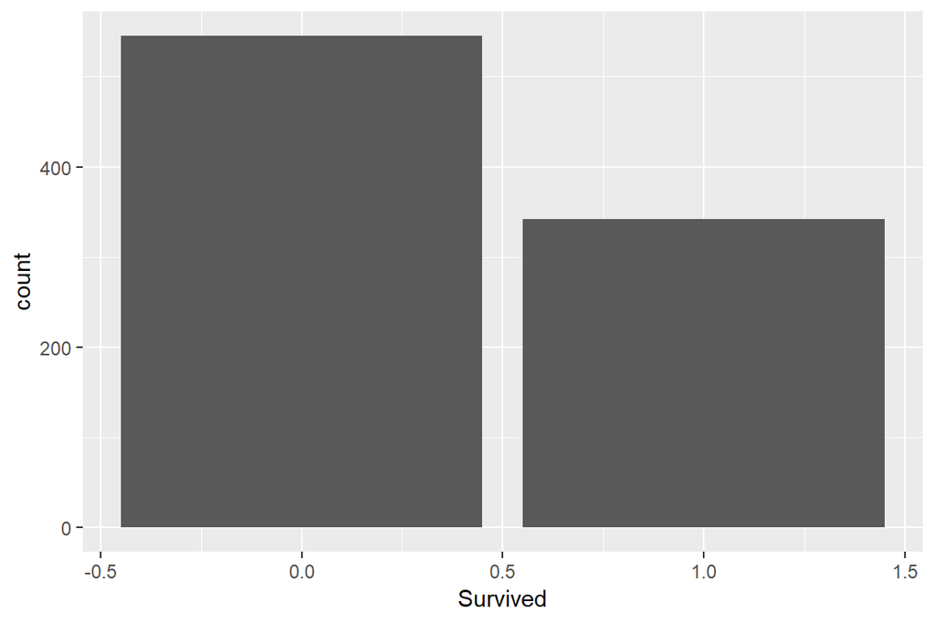

- Yikes, that’s ugly!
- Goal: Recode Survived to be a factor with values “Lived”, “Died”.

```r
titanic <- titanic %>%   # we are rewriting "titanic"
  mutate(
    Survived = factor(Survived,
                      levels = c(0,1), # old values
                      labels = c("Died", "Lived") # new values
    )
  )

# by naming the new variable "Survived", we overwrite the old one
```

- Check yourself: Did that work?

```r
titanic %>% count(Survived)
```

```
## # A tibble: 2 x 2
##   Survived     n
##   <fct>    <int>
## 1 Died       545
## 2 Lived      342
```

## Your Turn

- How many passengers were in each travel class?
- How many of each gender?
- How many of each gender *within* each travel class? Make a plot.

# Research question: Looking at specific individuals.

## Did the person with the most expensive ticket survive?

```r
titanic %>% top_n(1, Fare)
```

```
##   Survived Pclass                              Name    Sex Age
## 1    Lived      1                   Miss. Anna Ward female  35
## 2    Lived      1 Mr. Thomas Drake Martinez Cardeza   male  36
## 3    Lived      1             Mr. Gustave J Lesurer   male  35
##   Siblings.Spouses.Aboard Parents.Children.Aboard     Fare
## 1                       0                       0 512.3292
## 2                       0                       1 512.3292
## 3                       0                       0 512.3292
```

```r
# arrange(Fare) is okay too!
# But it prints ALL the answers
```

- Why did this give us 3 answers instead of 1 like we asked?

## Did the youngest person in third class survive?

```r
titanic %>% filter(Pclass == 3) %>% top_n(1, desc(Age))
```

```
##   Survived Pclass                           Name  Sex  Age
## 1    Lived      3 Master. Assad Alexander Thomas male 0.42
##   Siblings.Spouses.Aboard Parents.Children.Aboard   Fare
## 1                       0                       1 8.5167
```

## Your turn

- Did the richest woman in second class above the age of 30 survive?

# Research question: What explains why people lived or died?

## Gender

- Were men more likely to die than women?

```r
titanic %>% count(Sex, Survived)
```

```
## # A tibble: 4 x 3
##   Sex    Survived     n
##   <fct>  <fct>    <int>
## 1 female Died        81
## 2 female Lived      233
## 3 male   Died       464
## 4 male   Lived      109
```

- Hmmmm…. maybe.
- (Bonus: what statistical test would you use for this question?)
- What percent of passengers survived in each group (men vs women)?

```r
titanic %>%
  group_by(Sex) %>%
  summarize(pct_survived = mean(Survived == "Lived"))
```

```
## # A tibble: 2 x 2
##   Sex    pct_survived
##   <fct>         <dbl>
## 1 female        0.742
## 2 male          0.190
```

- (Think: Why did “mean” work?)
- (Try it: What does the output look like if you remove the last line and pipe?)
- We can also visualize the data to answer our question. Which plot will address the question better?

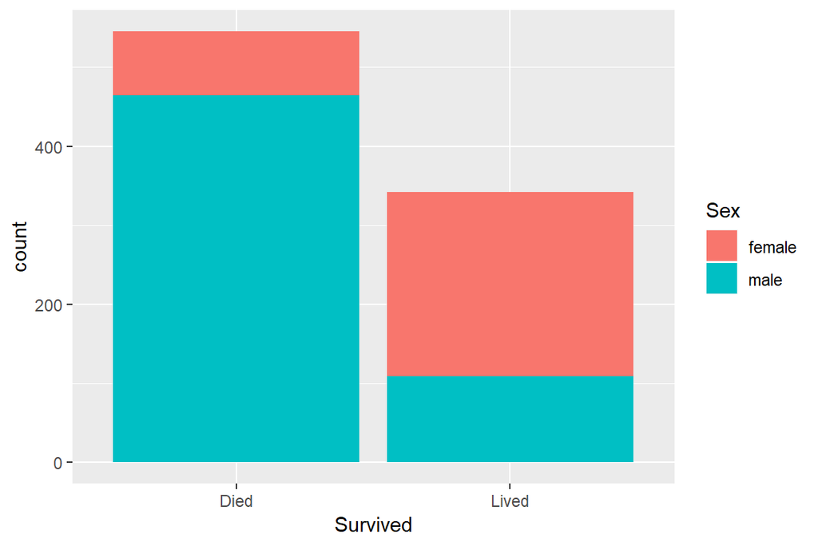

```r
titanic %>%
  ggplot(aes(x = Survived, fill = Sex)) + geom_bar()
```

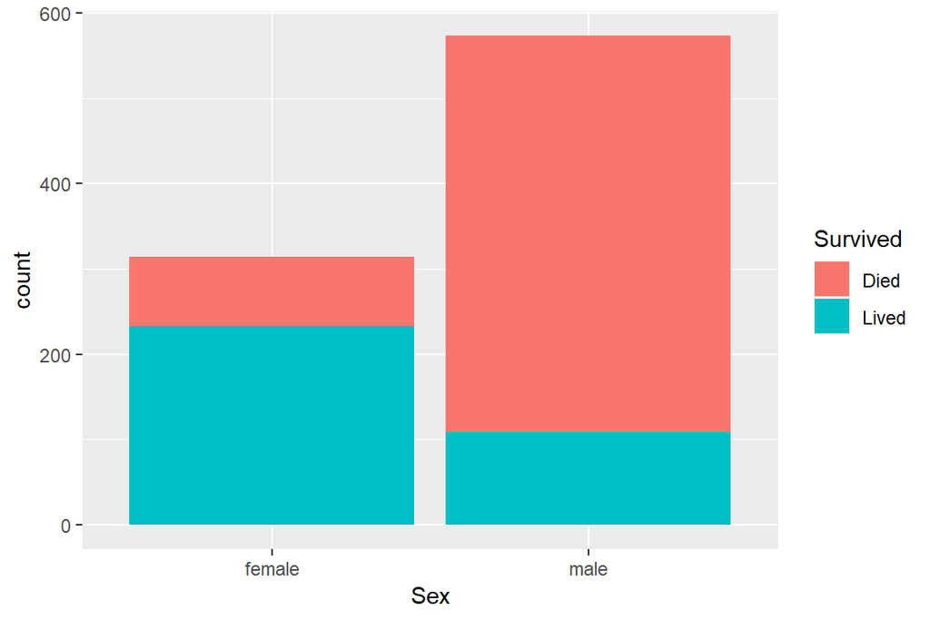

```r
titanic %>%
  ggplot(aes(x = Sex, fill = Survived)) + geom_bar()
```

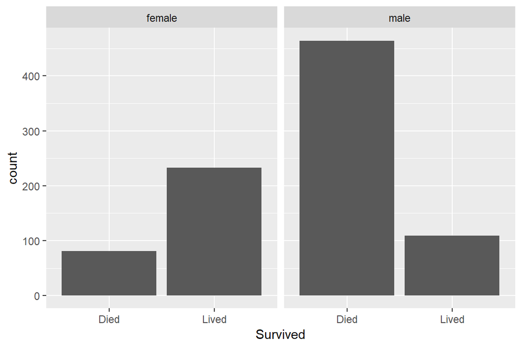

```r
titanic %>%
  ggplot(aes(x = Survived)) + geom_bar() + facet_wrap(~Sex)
```

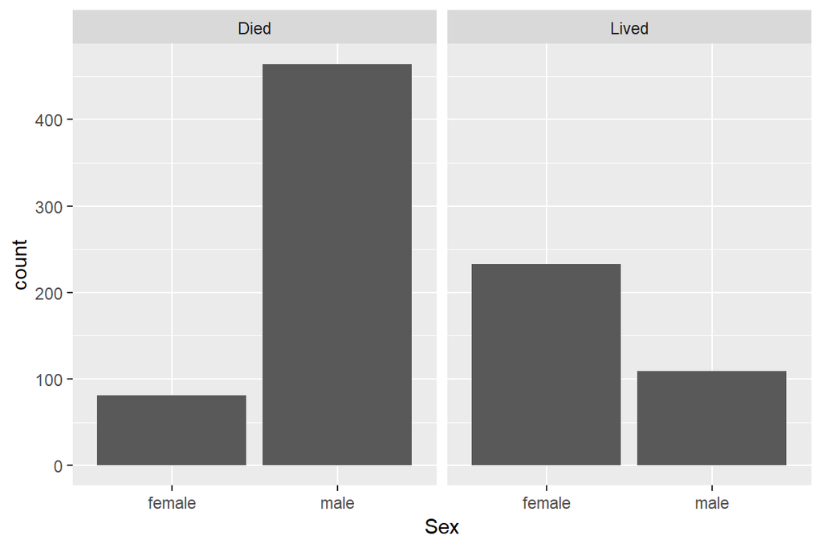

```r
titanic %>%
  ggplot(aes(x = Sex)) + geom_bar() + facet_wrap(~Survived)
```

- How can we best improve this plot to strengthen our point?

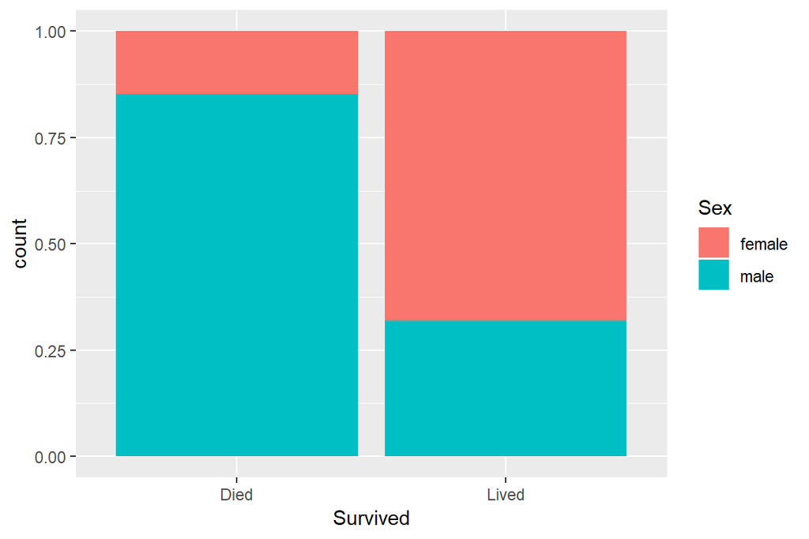

```r
titanic %>%
  ggplot(aes(x = Survived, fill = Sex)) + geom_bar(position = "fill")
```

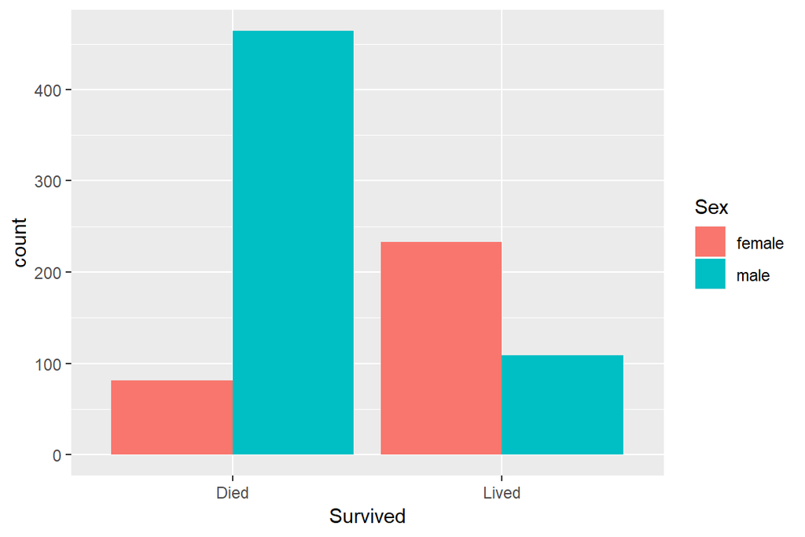

```r
titanic %>%
  ggplot(aes(x = Survived, fill = Sex)) + geom_bar(position = "dodge")
```

- What do you conclude?

## Your Turn

- Was one travel class more likely to survive than another?
- What is the relationship between gender, travel class, and survival?

# Extra practice

## Your turn

Try to use the same thought process with boxplots to answer these questions:

- Is there a price difference across the three classes?
- Is there an age difference across the three classes?

# Complex Research Question: What can we say about family, wealth, and survival?

## My thought process:

I’m not sure why we count siblings/spouses and parents/children separately. Let’s make new variables with clearer measurements.

```r
titanic <- titanic %>% mutate(
  Num.Family = Siblings.Spouses.Aboard + Parents.Children.Aboard,
  Has.Family = Num.Family > 0
)
```

Check that my variables worked

```r
titanic %>%
  select(Num.Family, Has.Family) %>%
  summary()
```

```
##    Num.Family      Has.Family
##  Min.   : 0.0000   Mode :logical
##  1st Qu.: 0.0000   FALSE:533
##  Median : 0.0000   TRUE :354
##  Mean   : 0.9087
##  3rd Qu.: 1.0000
##  Max.   :10.0000
```

Wealth can be measured in two ways: Class, or Fare. I would like to come up with categories based on these.

First, I want to know what the spread of Fare is.

```r
summary(titanic$Fare)
```

```
##    Min. 1st Qu.  Median    Mean 3rd Qu.    Max.
##   0.000   7.925  14.454  32.305  31.137 512.329
```

Alright, so most people paid less thatn $31, and some paid less than $8.

I think I will call people “Rich” if they are in 1st class or paid over $100, and “Poor” if they are in third class or paid less than $8.

```r
titanic <- titanic %>% mutate(
  wealth = case_when(
    Pclass == 3 | Fare < 8 ~ "Poor",
    Pclass == 1 | Fare > 100 ~ "Rich",
    TRUE ~ "Medium"
  ),
  wealth = factor(wealth, levels = c("Poor", "Medium", "Rich")) # reorder
)
```

Let me double check that my definitions split the population reasonably.

```r
titanic %>% count(wealth)
```

```
## # A tibble: 3 x 2
##   wealth     n
##   <fct>  <int>
## 1 Poor     499
## 2 Medium   178
## 3 Rich     210
```

Great, seems okay!

Now I need a plot. I think I would like to compare the number of family members for the various wealth levels, divided by whether they lived or died.

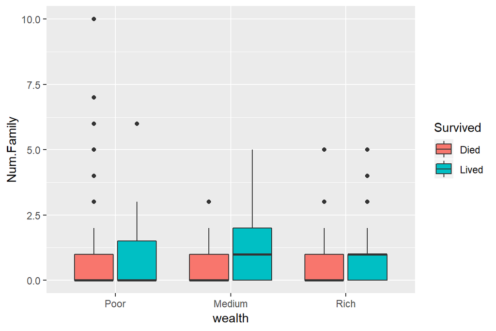

Hmmmm not so great. Perhaps simply if they had family or not would make more sense.

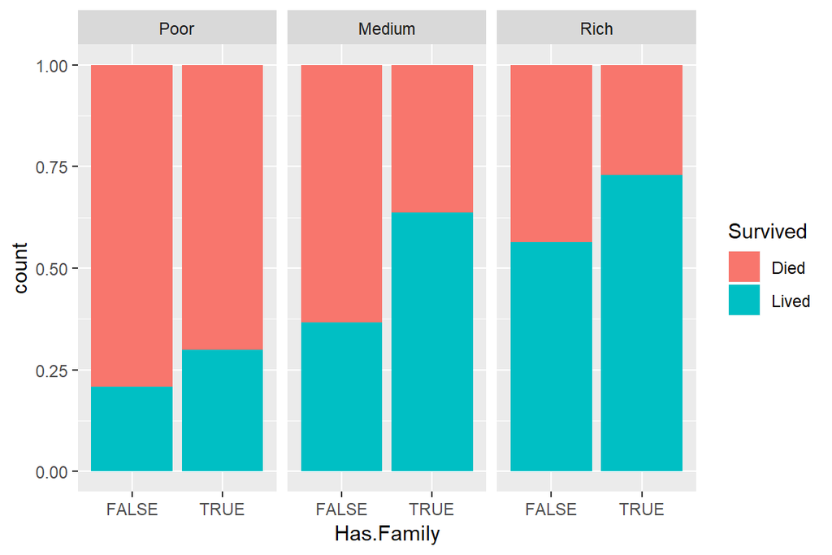

What do you conclude?

## YOUR TURN

Can you come up with different ways to address this question?